## Title: Severe weather events and related economic consequences across USA

## Synopsis

Severe weather events can case loss of life, injuries, significant property damage, and/or disruption to commerce. This report using NOAA Storm Data to summarize the top 10 harmful events related to population health and economic consequences due to the events.

## Data Processing

### Loading the data

The data was loaded from the [file repository](https://d396qusza40orc.cloudfront.net/repdata%2Fdata%2FStormData.csv.bz2) in the Reproducibal Research Coursera Course. The data was in the form of a comma-separated-value file compressed via the bzip2 algorithm.

```r
setwd("H:/Education/R/Project/StormData")
options(scipen = 999)
library(knitr)
library(stringr)
StormData <- read.csv("repdata_data_StormData.csv.bz2", stringsAsFactor = FALSE)
```

The file was downloaded, extracted and then read into a data frame named as StormData using the above codes.

### Clean the data

Event Type: All values are transformed into capital value and trimmed the leading and trailing whitespace.

Begin Date: remove the time zero and format to date type

Year of event: generate the year of event from begin date

Health Issues: generate the health problems due to the events, including injuries and fatalities.

Cost: sum the property damage and crop damage DMG with EXP.

```r
StormData$EVTYPE <- toupper(str_trim(StormData$EVTYPE))

StormData$BGN_DATE <- gsub(" 0:00:00", "", StormData$BGN_DATE)
StormData$BGN_DATE <- as.Date(StormData$BGN_DATE, "%m/%d/%Y")

StormData$YearEvent <- as.numeric(format(StormData$BGN_DATE, "%Y"))

StormData$HealthEvent <- with(StormData, INJURIES+FATALITIES)

exp_transform <- function(e) {
    if (e %in% c("b", "B"))
        return(9)
    else if (e %in% c("m", "M"))
        return(6)
    else if (e %in% c("k", "K"))
        return(3)
    else if (e %in% c("h", "H"))
        return(2)
    else {
        return(0)
    }
}
StormData$ProductCost <- StormData$PROPDMG * 10 ** sapply(StormData$PROPDMGEXP, FUN = exp_transform)
StormData$CropCost <- StormData$CROPDMG * 10 ** sapply(StormData$CROPDMGEXP, FUN = exp_transform)
StormData$Cost <- with(StormData, ProductCost + CropCost)
```

### Limit the year of data analysis

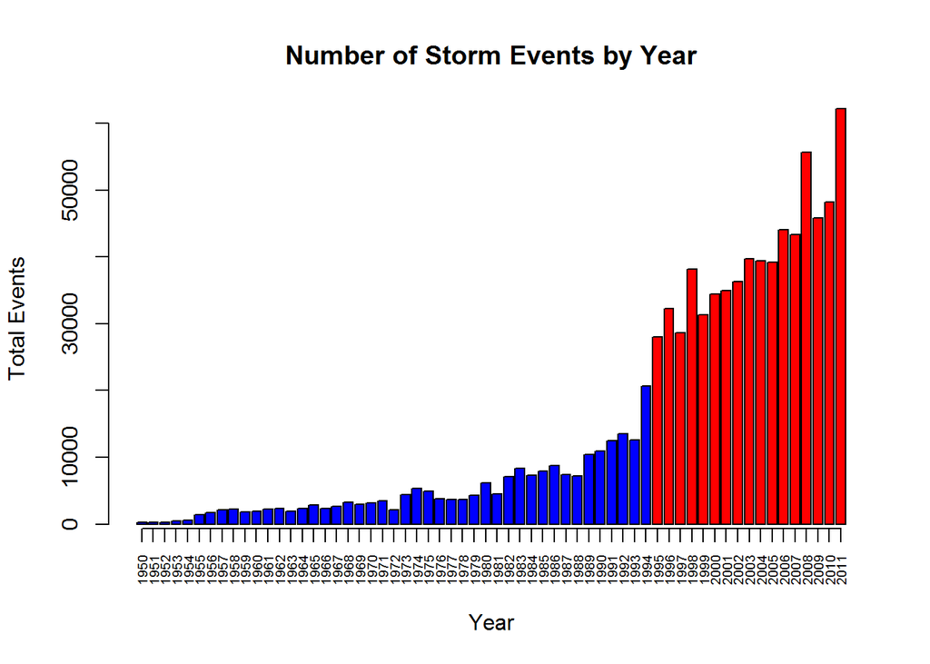

```r
RecordsByYear <- data.frame(with(StormData, table(YearEvent)))
RecordsByYear$YearEvent <- as.numeric(RecordsByYear$YearEvent) + 1949
cols <- c("blue", "red")[(RecordsByYear$YearEvent >= 1995) + 1]
par(las = 3)
barplot(RecordsByYear$Freq, names.arg = RecordsByYear$YearEvent,
    xlab = "Year", ylab = "Total Events",
    main = "Number of Storm Events by Year",
    axis.lty = 1, col = cols, cex.names = 0.6)
```

```r
SubsetData <- subset(StormData, StormData$YearEvent >= 1995)
```

### Result

1. Most harmful events with respect to population health

Aggregate the subset data to produce the top 10 events related to causality.

```r
EventsPop <- aggregate(HealthEvent~EVTYPE, data = SubsetData, FUN = "sum")
EventsPop <- EventsPop[order(-EventsPop$HealthEvent),][1:10,]
kable(EventsPop, format = "html", row.names = FALSE,
      col.names = c("Event Type", "Causality"),
      caption = "Top 10 Most Harmful Events with Respect to Population Health")
```

Top 10 Most Harmful Events with Respect to Population Health

| Event Type | Causality |
| --- | --- |
| TORNADO | 23310 |
| EXCESSIVE HEAT | 8428 |
| FLOOD | 7192 |
| LIGHTNING | 5360 |
| TSTM WIND | 3871 |
| HEAT | 2954 |
| FLASH FLOOD | 2668 |
| THUNDERSTORM WIND | 1557 |
| WINTER STORM | 1493 |
| HURRICANE/TYPHOON | 1339 |

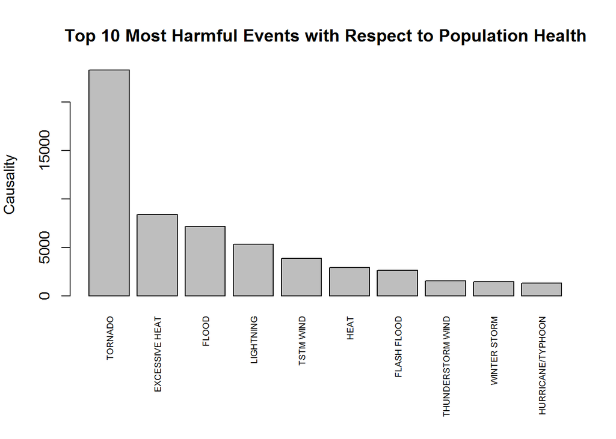

```r
par(las = 3)
par(mar = c(8, 4, 4, 2))
barplot(EventsPop$HealthEvent, names.arg = EventsPop$EVTYPE,
        ylab = "Causality", cex.name = 0.6,
        main = "Top 10 Most Harmful Events with Respect to Population Health")
```

From the table and plot, we can see tornado caused the highest causality, followed by excessive heat, flood, lightning, tstm wind, heat, flash flood, thunderstrom wind, winter storm and hurricane/typhoon.

2. Events with greatest economic consequences

Aggregate the subset dataset to produce the top 10 events with greatest economic consequences.

```r
EventsCost <- aggregate(Cost~EVTYPE, data = SubsetData, FUN = "sum")
EventsCost <- EventsCost[order(-EventsCost$Cost),][1:10,]
kable(EventsCost, format = "html", row.names = FALSE,
      col.names = c("Event Type", "Cost"))
```

| Event Type | Cost |
| --- | --- |
| FLOOD | 149444847457 |
| HURRICANE/TYPHOON | 71913712800 |
| STORM SURGE | 43193541000 |
| TORNADO | 25222315417 |
| HAIL | 17659849203 |
| FLASH FLOOD | 16709897660 |
| DROUGHT | 14968172000 |
| HURRICANE | 14554229010 |
| TROPICAL STORM | 8331171550 |
| HIGH WIND | 5893346675 |

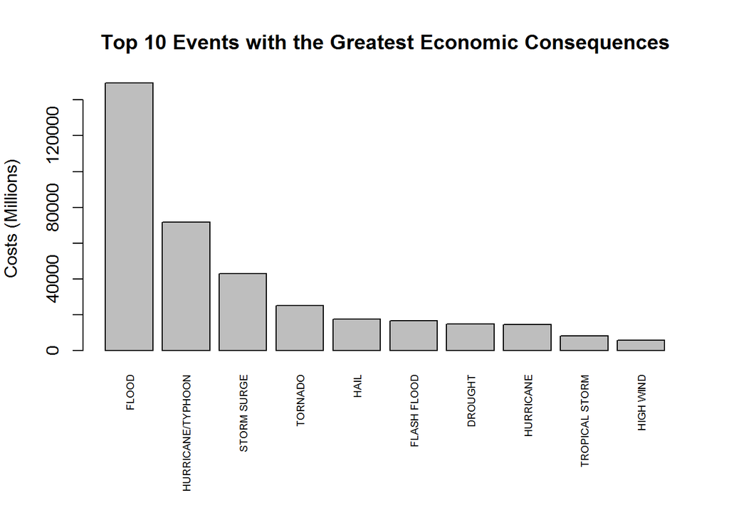

```r
par(las = 3)
par(mar = c(8, 4, 4, 2))
barplot(EventsCost$Cost * 10 ** -6, names.arg = EventsCost$EVTYPE,
        ylab = "Costs (Millions)", cex.names = 0.6,
        main = "Top 10 Events with the Greatest Economic Consequences")
```

Due to the limit time, events needs to be regrouped due to non-standarized data items.